# match data

#### vii) No. of matches won by each team.

```
winner
Mumbai Indians                 109
Chennai Super Kings            100
Kolkata Knight Riders           92
Royal Challengers Bangalore     84
Kings XI Punjab                 82
Rajasthan Royals                75
Delhi Daredevils                67
Sunrisers Hyderabad             58
Deccan Chargers                 29
Gujarat Lions                   13
Pune Warriors                   12
Rising Pune Supergiant          10
Delhi Capitals                  10
Kochi Tuskers Kerala             6
Rising Pune Supergiants          5
Name: count, dtype: int64
```

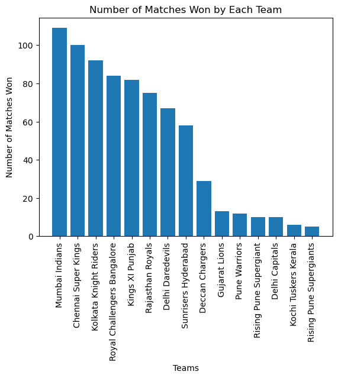

```python
import pandas as pd
import matplotlib.pyplot as plt

df = pd.read_csv("matches.csv")

team_wins = df['winner'].value_counts()

print(team_wins)

plt.figure()
plt.bar(team_wins.index, team_wins.values)

plt.xticks(rotation=90)
plt.xlabel("Teams")
plt.ylabel("Number of Matches Won")
plt.title("Number of Matches Won by Each Team")

plt.show()
```

#### Insights

- Top Winning Team: -Mumbai Indians has won the highest number of matches (around 110+ wins).
- Indicates strong consistency and multiple successful seasons.
- Second Highest: -Chennai Super Kings is close behind with around 100 wins.
- One of the most successful and consistent teams.
- Other Strong Performers:**

-Kolkata Knight Riders

-Royal Challengers Bangalore

-Kings XI Punjab

-Rajasthan Royals

#### viii) No. of matches held every season.

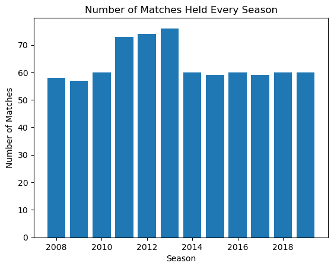

```python
import pandas as pd
import matplotlib.pyplot as plt

df = pd.read_csv("matches.csv")

season_matches = df['season'].value_counts().sort_index()

plt.figure()
plt.bar(season_matches.index, season_matches.values)

plt.xlabel("Season")
plt.ylabel("Number of Matches")
plt.title("Number of Matches Held Every Season")

plt.show()
```

#### Insights

-nitial Seasons (2008–2010): -The number of matches was around 57–60 matches per season.

- Expansion Period (2011–2013): -There was a noticeable increase to around 73–76 matches.
- This likely happened because more teams participated during these seasons.
- Stabilization (2014 onwards): -After 2013, the number of matches reduced and remained mostly stable around 59–60 matches per season.

#### ix) Top 10 players based on no. of Man of Match (MOM) awards won.

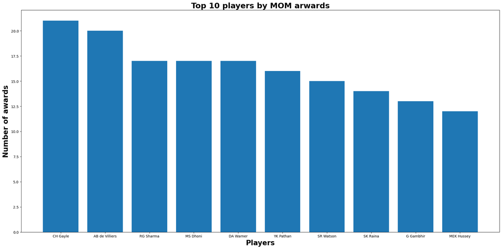

```python
import pandas as pd
import matplotlib.pyplot as plt

df = pd.read_csv("matches.csv")

top_players = df['player_of_match'].value_counts().head(10)

plt.figure(figsize=(20,10))
plt.bar(top_players.index, top_players.values)

plt.xlabel("Players",fontweight='bold',fontsize=20)
plt.ylabel("Number of awards",fontweight='bold',fontsize=20)
plt.title("Top 10 players by MOM arwards",fontweight='bold',fontsize=22)

plt.tight_layout()
plt.show()
```

#### Insights

-Highest Awards: -Chris Gayle holds the highest percentage (~13%) of Man of the Match awards among the top 10 players. -Shows his match-winning impact. -Close Competitors:**

-AB de Villiers (~12.3%)

-Rohit Sharma (~10.5%)

-MS Dhoni (~10.5%)

-David Warner (~10.5%)

-Strong All-Round Performers:**

-Yusuf Pathan

-Shane Watson

-Suresh Raina

-Gautam Gambhir

-Michael Hussey

#### x) Does winning the toss mean winning the match?

[figure not shown]

```python
import matplotlib.pyplot as plt

labels = ['Lost after winning toss', 'Won after winning toss']

plt.figure()
plt.pie(result_counts, labels=labels, autopct='%1.1f%%')
plt.title("Does winning toss mean winning the match", fontweight='bold', fontsize=20)
plt.show()
```

#### Insights

-Toss winners have a slight edge: Teams that won the toss also won more matches overall, but the difference compared to toss losers is not dramatic.

#### xi) What was the decision taken by captains when they won the toss?

```
toss_decision
field    463
bat      293
Name: count, dtype: int64
```

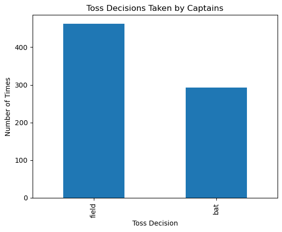

```python
import pandas as pd
import matplotlib.pyplot as plt

matches = pd.read_csv("matches.csv")

decision_count = matches["toss_decision"].value_counts()

print(decision_count)

plt.figure()
decision_count.plot(kind="bar")
plt.title("Toss Decisions Taken by Captains")
plt.xlabel("Toss Decision")
plt.ylabel("Number of Times")
plt.show()
```

#### Insights

-Key Observations

- Captains prefer fielding: The bar for "field" is much taller, showing that captains overwhelmingly choose to field after winning the toss.
- Strategic reasoning:
- In limited-overs formats (ODIs and T20s), chasing is often seen as easier because teams know the target and can pace their innings accordingly.
- Factors like dew in night matches make batting second advantageous, since the ball skids on and is harder for bowlers to grip.

#### xii) No. of matches where D/L method was applied every season.

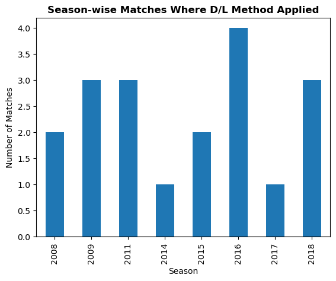

```python
import pandas as pd
import matplotlib.pyplot as plt

df = pd.read_csv("matches.csv")

dl_matches = df[df['dl_applied'] == 1]

dl_count_season = dl_matches.groupby('season').size()

plt.figure()
dl_count_season.plot(kind='bar')
plt.title("Season-wise Matches Where D/L Method Applied", fontweight='bold')
plt.xlabel("Season")
plt.ylabel("Number of Matches")
plt.show()
```